# Clinical Survival Analysis

Qian Stefens

2026-07-29

# Introduction

This report evaluates clinical survival data from the veteran lung cancer trial (from the R survival package). The analysis aims to answer two key research questions: “Does histological cell type significantly influence patient survival time?” and “Is there a significant difference in survival times between the standard treatment group and the experimental test treatment group?”

# Exploratory Data Analysis

```
## 'data.frame':    137 obs. of  8 variables:
##  $ trt     : num  1 1 1 1 1 1 1 1 1 1 ...
##  $ celltype: Factor w/ 4 levels "squamous","smallcell",..: 1 1 1 1 1 1 1 1 1 1 ...
##  $ time    : num  72 411 228 126 118 10 82 110 314 100 ...
##  $ status  : num  1 1 1 1 1 1 1 1 1 0 ...
##  $ karno   : num  60 70 60 60 70 20 40 80 50 70 ...
##  $ diagtime: num  7 5 3 9 11 5 10 29 18 6 ...
##  $ age     : num  69 64 38 63 65 49 69 68 43 70 ...
##  $ prior   : num  0 10 0 10 10 0 10 0 0 0 ...
```

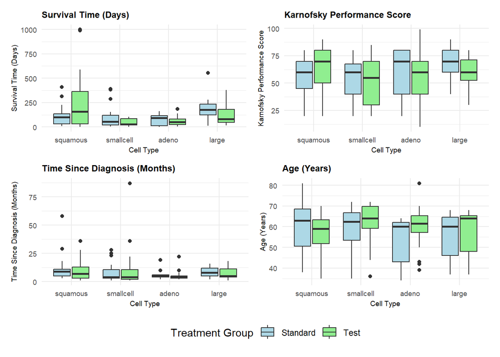

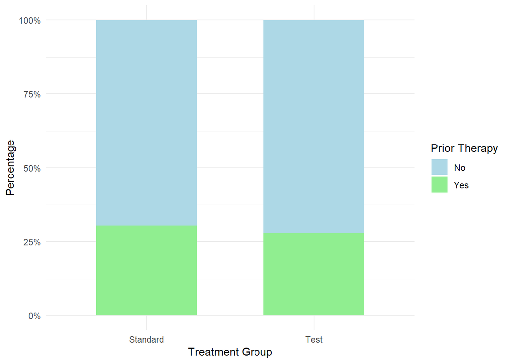

| **Variable** | **N** | **1** N = 69<sup>1</sup> | **2** N = 68<sup>1</sup> |
| --- | --- | --- | --- |
| celltype | 137 |  |  |
| squamous |  | 15 (22%) | 20 (29%) |
| smallcell |  | 30 (43%) | 18 (26%) |
| adeno |  | 9 (13%) | 18 (26%) |
| large |  | 15 (22%) | 12 (18%) |
| time | 137 | 97 (25, 153) | 53 (25, 123) |
| status | 137 | 64 (93%) | 64 (94%) |
| karno | 137 | 60 (40, 80) | 60 (40, 70) |
| diagtime | 137 | 5 (4, 11) | 5 (3, 11) |
| age | 137 | 62 (49, 66) | 62 (52, 66) |
| prior | 137 |  |  |
| 0 |  | 48 (70%) | 49 (72%) |
| 10 |  | 21 (30%) | 19 (28%) |

<sup>1</sup> n (%); Median (Q1, Q3)

The distributions of Karnofsky score, age, and prior seem to be well balanced between the cell types and treatment groups.

# Univariate Survival Analysis - Kaplan Meier

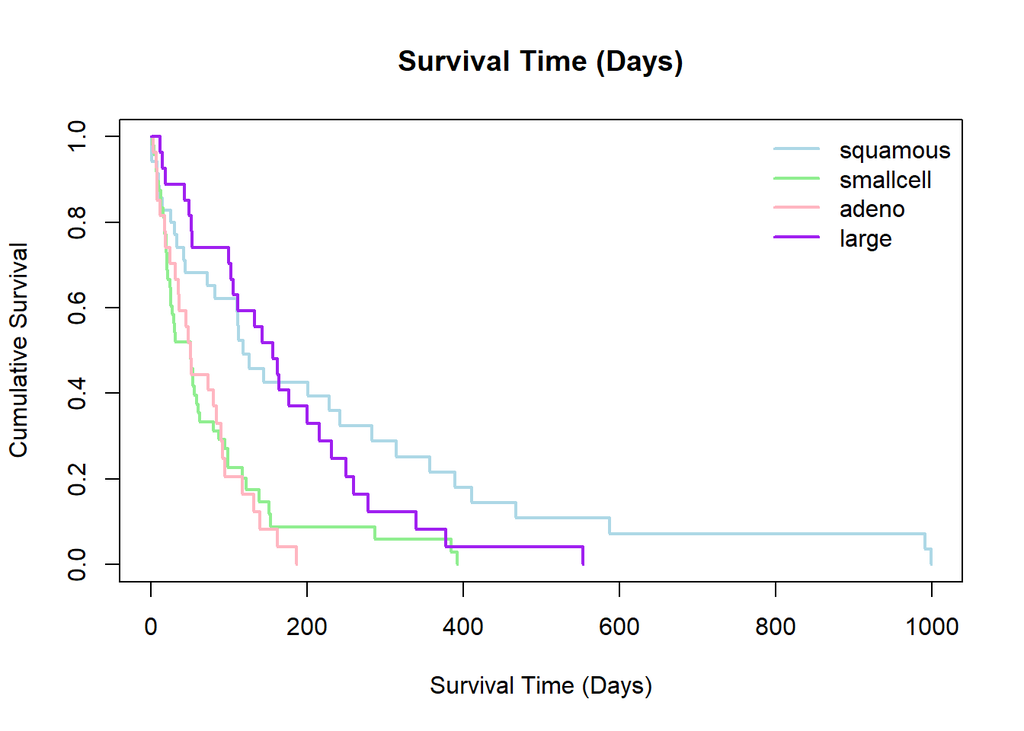

| Chi-Square | df | p-value |
| --- | --- | --- |
| 25.4 | 3 | <0.001 |

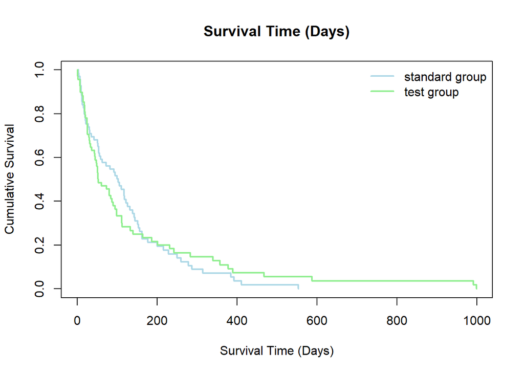

The kaplan-Meier survival curves for the standard and test treatment groups overlap fairly closely. A log-rank test indicates that no statistically significant difference in overall survival between the two treatments is found ($\chi^2 = 0.0$, $df = 1$, $p = 0.928$).

| Chi-Square | df | p-value |
| --- | --- | --- |
| 0.01 | 1 | 0.928 |

# Multivariate Cox Regression

A multivariate Cox Regression was conducted to assess the treatment effect while adjusting for the other covariates. Initial analysis via Schoenfeld residuals showed that celltype ($p = 0.002$) and Karnofsky performance score ($p < 0.001$) violated the proportional hazards assumption. To resolve this, the model was adjusted by stratifying for the Karnofsky performance score. This successfully restored the global model assumption ($p = 0.053$).

| term | chisq (Initial) | df (Initial) | p (Initial) | chisq (Stratified) | df (Stratified) | p (Stratified) |
| --- | --- | --- | --- | --- | --- | --- |
| trt | 0.264 | 1 | 0.607 | 1.168 | 1 | 0.280 |
| celltype | 15.227 | 3 | 0.002 | 4.870 | 3 | 0.182 |
| karno | 12.935 | 1 | 0.000 | NA | NA | NA |
| diagtime | 0.013 | 1 | 0.910 | 0.033 | 1 | 0.856 |
| age | 1.829 | 1 | 0.176 | 4.111 | 1 | 0.043 |
| prior | 2.166 | 1 | 0.141 | 2.931 | 1 | 0.087 |
| GLOBAL | 34.552 | 8 | 0.000 | 13.926 | 7 | 0.053 |

```
##                   GVIF Df GVIF^(1/(2*Df))
## trt           1.148510  1        1.071685
## celltype      1.188688  3        1.029227
## strata(karno) 3.528813  0             Inf
## diagtime      1.317548  1        1.147845
## age           1.055413  1        1.027333
## prior         1.316183  1        1.147250
```

| **Characteristic** | **HR** | **95% CI** | **p-value** |
| --- | --- | --- | --- |
| trt | 1.10 | 0.72, 1.68 | 0.672 |
| celltype |  |  |  |
| squamous | — | — |  |
| smallcell | 2.50 | 1.37, 4.57 | 0.003 |
| adeno | 3.31 | 1.70, 6.41 | <0.001 |
| large | 1.21 | 0.64, 2.29 | 0.554 |
| diagtime | 0.99 | 0.97, 1.01 | 0.367 |
| age | 1.00 | 0.98, 1.02 | 0.842 |
| prior | 1.01 | 0.97, 1.06 | 0.602 |

Abbreviations: CI = Confidence Interval, HR = Hazard Ratio

# Conclusion

The survival analysis demonstrates that the test treatment provides no statistically signficant advantage in survival time compared to the standard treatment ($p = 0.672$). Instead, patient prognosis is more driven by tumor histology. Specifically, tumor cell types such as adeno and small cell type are associated with a large increase in the hazard of death compared to squamous cell type ($p \le 0.003$).